# R Notebook

# Effect of Mass Transport Systems and Economic output.

```r
library(stargazer)
library(tidyverse)
library(skimr)
library(ggplot2)
library(imputeTS)
library(did)
library(stargazer)
library(recipes)
library(did2s)
library(fixest)
```

```r
# load Santiago city data file
stgo <- read_csv("/Users/hendrixperalta/Downloads/Projects/Will-A-Subway-Line-Reduce-Transit-related-Deaths/stgo.csv")
```

```r
# load Santo Domingo city data file
sd <- read_csv("/Users/hendrixperalta/Downloads/Projects/Will-A-Subway-Line-Reduce-Transit-related-Deaths/sd.csv")
```

```r
# 2013 - 2020 period is choosen due to data availability

sd_13_20 <- sd %>% filter(year >= 2013 & year <= 2020)
```

```r
skim(sd_13_20) %>% as.tibble
```

| skim_type | skim_variable | n_missing | complete_rate | numeric.mean | numeric.sd | numeric.p0 | numeric.p25 | numeric.p50 | numeric.p75 | numeric.p100 | numeric.hist |
| --- | --- | --- | --- | --- | --- | --- | --- | --- | --- | --- | --- |
| numeric | year | 0 | 1.00 | 2.016500e+03 | 2.449490e+00 | 2.013000e+03 | 2.014750e+03 | 2.016500e+03 | 2.018250e+03 | 2.020000e+03 | ▇▃▇▃▇ |
| numeric | births | 0 | 1.00 | 3.241988e+04 | 4.005549e+03 | 2.770000e+04 | 2.927475e+04 | 3.157300e+04 | 3.531350e+04 | 3.813000e+04 | ▇▂▂▂▅ |
| numeric | car_theft | 0 | 1.00 | 1.749875e+03 | 3.748285e+02 | 1.300000e+03 | 1.541000e+03 | 1.675500e+03 | 1.967000e+03 | 2.442000e+03 | ▅▇▂▂▂ |
| numeric | transit_death | 0 | 1.00 | 9.193750e+02 | 1.177988e+02 | 7.300000e+02 | 8.482500e+02 | 9.245000e+02 | 9.792500e+02 | 1.118000e+03 | ▃▇▇▇▃ |
| numeric | hospital_emergency | 0 | 1.00 | 1.016597e+06 | 2.237251e+05 | 6.209180e+05 | 9.407748e+05 | 1.072414e+06 | 1.162660e+06 | 1.250465e+06 | ▅▁▁▇▇ |
| numeric | homicide | 0 | 1.00 | 4.328750e+02 | 1.220075e+02 | 3.340000e+02 | 3.595000e+02 | 3.750000e+02 | 4.697500e+02 | 6.620000e+02 | ▇▂▁▂▂ |
| numeric | co2_mean | 2 | 0.75 | 4.066565e+02 | 5.283212e+00 | 3.985716e+02 | 4.035531e+02 | 4.076873e+02 | 4.103514e+02 | 4.125785e+02 | ▃▃▃▃▇ |
| numeric | medical_checks | 0 | 1.00 | 1.238375e+06 | 3.536952e+05 | 5.464730e+05 | 1.217454e+06 | 1.370125e+06 | 1.421157e+06 | 1.543957e+06 | ▁▁▁▁▇ |
| numeric | pop_density | 0 | 1.00 | 2.094720e+03 | 9.704300e+01 | 1.954809e+03 | 2.025979e+03 | 2.095206e+03 | 2.164547e+03 | 2.232227e+03 | ▇▃▇▃▇ |
| numeric | pop | 0 | 1.00 | 2.726990e+06 | 1.263345e+05 | 2.544848e+06 | 2.637500e+06 | 2.727624e+06 | 2.817894e+06 | 2.906003e+06 | ▇▃▇▃▇ |

[output cut: 2 more lines]

```r
# Transform the variable year to numeric
# Create a post variable indicating the treatment period
# Create a post_factor variable that labels the periods of pre and post treatment
# Only the variables year, homicide, medical_checks, pop, ntl, pm25, transit_death, post and post_factor are selected

sd_fix <- sd_13_20 %>%
  mutate(
    year = as.integer(year),
    post = ifelse(year >= 2018, 1, 0),
    post_factor = factor(post , labels = c("Pre-Treatment", "Post-Treatment"))
  ) %>%
  select(year, homicide, medical_checks, pop, ntl, pm25, transit_death, post, post_factor)
```

```r
# No missing values in the data set

skim(sd_fix) %>% as.tibble
```

| skim_type | skim_variable | n_missing | complete_rate | factor.ordered | factor.n_unique | factor.top_counts | numeric.mean | numeric.sd | numeric.p0 | numeric.p25 | numeric.p50 | numeric.p75 | numeric.p100 | numeric.hist |
| --- | --- | --- | --- | --- | --- | --- | --- | --- | --- | --- | --- | --- | --- | --- |
| factor | post_factor | 0 | 1 | FALSE | 2 | Pre: 5, Pos: 3 | NA | NA | NA | NA | NA | NA | NA | NA |
| numeric | year | 0 | 1 | NA | NA | NA | 2.016500e+03 | 2.449490e+00 | 2.013000e+03 | 2.014750e+03 | 2.016500e+03 | 2.018250e+03 | 2.020000e+03 | ▇▃▇▃▇ |
| numeric | homicide | 0 | 1 | NA | NA | NA | 4.328750e+02 | 1.220075e+02 | 3.340000e+02 | 3.595000e+02 | 3.750000e+02 | 4.697500e+02 | 6.620000e+02 | ▇▂▁▂▂ |
| numeric | medical_checks | 0 | 1 | NA | NA | NA | 1.238375e+06 | 3.536952e+05 | 5.464730e+05 | 1.217454e+06 | 1.370125e+06 | 1.421157e+06 | 1.543957e+06 | ▁▁▁▁▇ |
| numeric | pop | 0 | 1 | NA | NA | NA | 2.726990e+06 | 1.263345e+05 | 2.544848e+06 | 2.637500e+06 | 2.727624e+06 | 2.817894e+06 | 2.906003e+06 | ▇▃▇▃▇ |
| numeric | ntl | 0 | 1 | NA | NA | NA | 6.828683e+00 | 1.013770e+00 | 5.844736e+00 | 6.114845e+00 | 6.419317e+00 | 7.455766e+00 | 8.383809e+00 | ▇▂▂▁▃ |
| numeric | pm25 | 0 | 1 | NA | NA | NA | 1.321498e+01 | 6.387067e-01 | 1.232513e+01 | 1.277859e+01 | 1.324876e+01 | 1.358426e+01 | 1.418870e+01 | ▇▃▇▃▇ |
| numeric | transit_death | 0 | 1 | NA | NA | NA | 9.193750e+02 | 1.177988e+02 | 7.300000e+02 | 8.482500e+02 | 9.245000e+02 | 9.792500e+02 | 1.118000e+03 | ▃▇▇▇▃ |
| numeric | post | 0 | 1 | NA | NA | NA | 3.750000e-01 | 5.175492e-01 | 0.000000e+00 | 0.000000e+00 | 0.000000e+00 | 1.000000e+00 | 1.000000e+00 | ▇▁▁▁▅ |

### Linear Regression

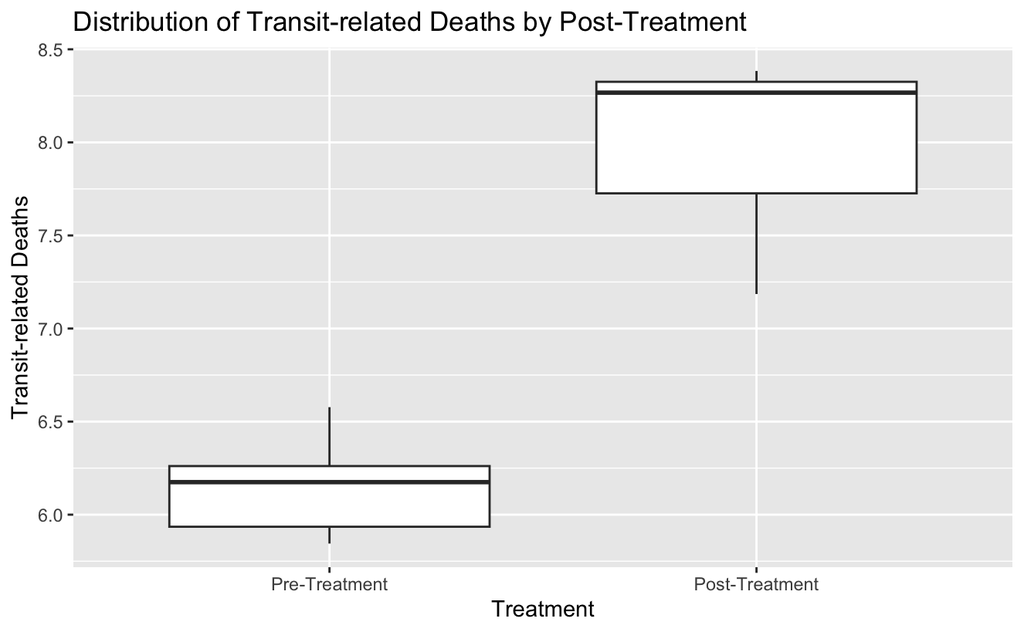

```r
# Create a box plot for each group of 'post'

ggplot(sd_fix, aes(x = post_factor, y = ntl)) +
  geom_boxplot() +
  labs(x = "Treatment", y = "Transit-related Deaths",
       title = "Distribution of Transit-related Deaths by Post-Treatment")
```

We can observe that nightime lights present different distributions before and after the treatment. On that regard, the mean and median of nighttime Lights is higher in the post treatment group hinting a correlation between the introduction of mastransportation systems to the Santo Domingo city and economic output.

```r
# Definition of the regression models

model_1 <- lm(ntl ~ post, data = sd_fix)
model_2 <- lm(ntl ~ post + medical_checks , data = sd_fix)
model_3 <- lm(ntl ~ post + medical_checks + transit_death, data = sd_fix)
model_4 <- lm(ntl ~ post + medical_checks + transit_death + homicide , data = sd_fix)
#model_5 <- lm(transit_death ~ post + medical_full + ntl_root + homicide_root + pm25, data = sd_fix)
#model_6 <- lm(transit_death ~ post + medical_full + ntl_root + homicide_root + pm25 + pop, data = sd_fix)


#ntl_root, homicide_root, medical_full, pop, pm25, post, transit_death
```

```r
residual_1 <- resid(model_1)
residual_2 <- resid(model_2)
residual_3 <- resid(model_3)
residual_4 <- resid(model_4)
#residual_5 <- resid(model_5)
#residual_6 <- resid(model_6)
```

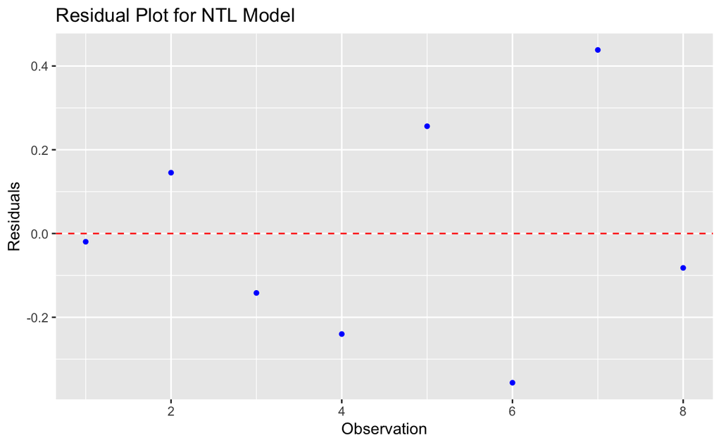

```r
# Creates a plot to check for patterns in the regression residuals

ggplot(data = data.frame(residual_4)) +
  geom_point(aes(x = seq_along(residual_4), y = residual_4), pch = 16, col = "blue") +
  geom_hline(yintercept = 0, linetype = "dashed", color = "red") +
  labs(x = "Observation", y = "Residuals", title = "Residual Plot for NTL Model")
```

there are no visible patterns on the residuals of the regression indicating that there is no heteroschedasticity on our dataset.

```r
# Regression table - includes the 4 regression models

variable_names <- c(
  "post" = "Post Subway",
  "medical_checks" = "Access to Healthcare",
  "transit_death" = "Transport Related Deaths",
  "homicide" = "Social Insecurity"
)

stargazer(model_1, model_2, model_3, model_4,
          type = "text", covariate.labels = variable_names,
          notes = c("GDP = Masked Mean Nighttime Lights",
                    "Pollution = Count of Particule Matter PM 2.5",
                    "Access to Healthcare = Count of Medical Checks in Public Facilities",
                    "Social Insecurity = Count of homicides cases"))
```

```
=============================================================================================================
                                                         Dependent variable:
                         ------------------------------------------------------------------------------------
                                                                 ntl
                                  (1)                  (2)                  (3)                  (4)
-------------------------------------------------------------------------------------------------------------
Post Subway                    1.787***              1.755***             1.908***              1.509*
                                (0.328)              (0.361)              (0.313)              (0.514)

Access to Healthcare                                 -0.00000             -0.00000             -0.00000
                                                    (0.00000)            (0.00000)            (0.00000)

Transport Related Deaths                                                   -0.002               -0.001
                                                                          (0.001)              (0.002)

Social Insecurity                                                                               -0.002
                                                                                               (0.002)

Constant                       6.159***              6.445***             8.470***             8.807***
                                (0.201)              (0.716)              (1.279)              (1.331)

-------------------------------------------------------------------------------------------------------------
Observations                       8                    8                    8                    8
R2                               0.832                0.838                0.910                0.932
Adjusted R2                      0.804                0.773                0.842                0.841
Residual Std. Error         0.449 (df = 6)        0.483 (df = 5)       0.403 (df = 4)       0.404 (df = 3)
F Statistic              29.728*** (df = 1; 6) 12.909** (df = 2; 5) 13.462** (df = 3; 4) 10.245** (df = 4; 3)
=============================================================================================================
Note:                                                                             *p<0.1; **p<0.05; ***p<0.01
                                                                           GDP = Masked Mean Nighttime Lights
                                                                 Pollution = Count of Particule Matter PM 2.5
                                          Access to Healthcare = Count of Medical Checks in Public Facilities
                                                                 Social Insecurity = Count of homicides cases
```

In the table we can observe that the post dummy variable indicating the introduction of the mass transportation system have big and statistical significance in all 4 models.

### Difference in Differences

```r
# 2013 - 2020 period is choosen due to data availability

stgo_13_20 <- stgo %>% filter(year >= 2013 & year <= 2020)
```

```r
stgo_fix <- stgo_13_20 %>%

# Transform the variable year to numeric
# Create a "post" variable indicating the treatment period
# Create a "post_factor" variable that labels the periods of pre and post treatment
# Only the variables year, homicide, medical_checks, pop, ntl, pm25, transit_death, post and post_factor are selected

  mutate(
    year = as.integer(year),
    post = ifelse(year >= 2018, 1, 0),
    post_factor = factor(post , labels = c("Pre-Treatment", "Post-Treatment"))
  ) %>%
  select(year, homicide, medical_checks, pop, ntl, pm25, transit_death, post, post_factor)
```

```r
# Create variable "treat" to indicate if it is the treatment or control group (used with did library)
# Craate variable "id" to indicate if it is the treatment or control group (used with fixest and did2s libraries)
# Scale variables bt population to make them comparable

sd_did <- sd_fix %>% mutate(
    treat = TRUE,
    id = "santo Domingo",
    year = as.integer(year),
    death_pop = transit_death/(pop/1000),
    homicide_pop = homicide/(pop/1000),
    medical_pop = medical_checks/(pop/1000)
)

stgo_did <- stgo_fix %>% mutate(
    treat = FALSE,
    id = "santiago",
    year = as.integer(year),
    death_pop = transit_death/(pop/1000),
    homicide_pop = homicide/(pop/1000),
    medical_pop = medical_checks/(pop/1000)
)
```

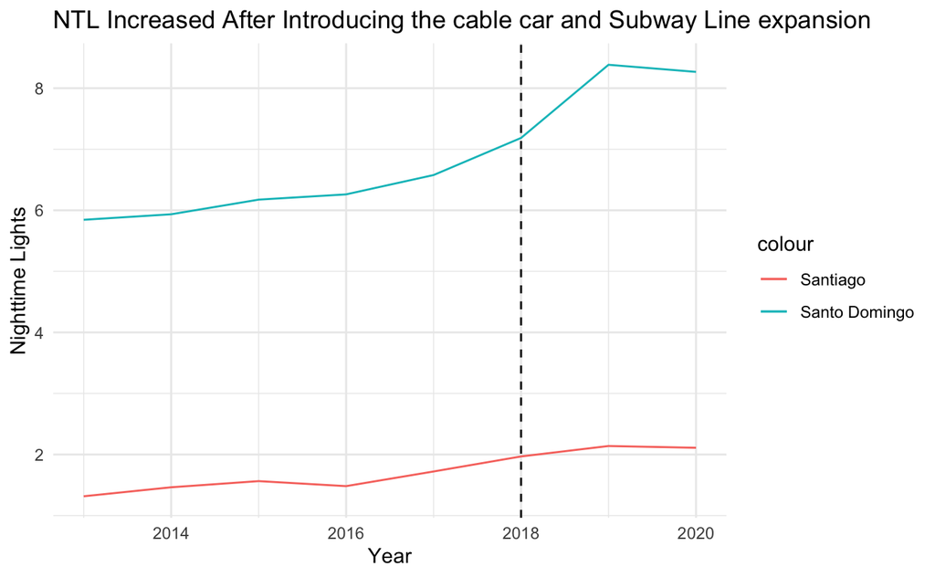

```r
ggplot()+
geom_line(data = sd_did, aes(x = year, y = ntl, color = "Santo Domingo", ))+
geom_line(data = stgo_did, aes(x = year, y = ntl, color = "Santiago")) +
geom_vline(xintercept = 2018, linetype = "dashed", color =  "black") +
xlab("Year") +
  ylab("Nighttime Lights") +
  ggtitle("NTL Increased After Introducing the cable car and Subway Line expansion") +
  theme_minimal()
```

In the grapgh we can observe an increase in NTL in Santo Domingo after the instroduction of the MTS in 2018

```r
# Combine the data for Satiago and Santo Domingo in 1 dataset

combined_data <- bind_rows(sd_did, stgo_did)
```

```r
skim(combined_data)
```

```
── Data Summary ────────────────────────
                           Values
Name                       combined_data
Number of rows             16
Number of columns          14
_______________________
Column type frequency:
  character                1
  factor                   1
  logical                  1
  numeric                  11
________________________
Group variables            None
```

|  | skim_variable | n_missing | complete_rate | min | max | empty | n_unique | whitespace |
| --- | --- | --- | --- | --- | --- | --- | --- | --- |
| 1 | id | 0 | 1 | 8 | 13 | 0 | 2 | 0 |

|  | skim_variable | n_missing | complete_rate | ordered | n_unique | top_counts |
| --- | --- | --- | --- | --- | --- | --- |
| 1 | post_factor | 0 | 1 | FALSE | 2 | Pre: 10, Pos: 6 |

|  | skim_variable | n_missing | complete_rate | mean | count |
| --- | --- | --- | --- | --- | --- |
| 1 | treat | 0 | 1 | 0.5 | FAL: 8, TRU: 8 |

|  | skim_variable | n_missing | complete_rate | mean | sd | p0 | p25 | p50 | p75 | p100 | hist |
| --- | --- | --- | --- | --- | --- | --- | --- | --- | --- | --- | --- |
| 1 | year | 0 | 1 | 2.016500e+03 | 2.366432e+00 | 2.013000e+03 | 2.014750e+03 | 2.016500e+03 | 2.018250e+03 | 2.020000e+03 | ▇▃▇▃▇ |
| 2 | homicide | 0 | 1 | 3.047500e+02 | 1.580749e+02 | 1.120000e+02 | 1.862500e+02 | 2.705000e+02 | 3.725000e+02 | 6.620000e+02 | ▇▁▆▁▂ |
| 3 | medical_checks | 0 | 1 | 1.036848e+06 | 3.363841e+05 | 4.635950e+05 | 8.440488e+05 | 9.213255e+05 | 1.358669e+06 | 1.543957e+06 | ▂▇▃▁▇ |
| 4 | pop | 0 | 1 | 1.872992e+06 | 8.863085e+05 | 9.919330e+05 | 1.021036e+06 | 1.795008e+06 | 2.714826e+06 | 2.906003e+06 | ▇▁▁▁▇ |
| 5 | ntl | 0 | 1 | 4.274794e+00 | 2.735584e+00 | 1.316300e+00 | 1.682774e+00 | 3.992105e+00 | 6.340194e+00 | 8.383809e+00 | ▇▁▁▅▃ |
| 6 | pm25 | 0 | 1 | 1.298964e+01 | 7.320828e-01 | 1.176809e+01 | 1.251954e+01 | 1.298367e+01 | 1.336690e+01 | 1.422483e+01 | ▃▇▅▅▅ |
| 7 | transit_death | 0 | 1 | 6.338750e+02 | 3.100976e+02 | 2.550000e+02 | 3.780000e+02 | 5.905000e+02 | 9.097500e+02 | 1.118000e+03 | ▇▁▁▃▅ |
| 8 | post | 0 | 1 | 3.750000e-01 | 5.000000e-01 | 0.000000e+00 | 0.000000e+00 | 0.000000e+00 | 1.000000e+00 | 1.000000e+00 | ▇▁▁▁▅ |
| 9 | death_pop | 0 | 1 | 3.399862e-01 | 6.099026e-02 | 2.511333e-01 | 2.874315e-01 | 3.433537e-01 | 3.880657e-01 | 4.375578e-01 | ▆▅▃▇▃ |
| 10 | homicide_pop | 0 | 1 | 1.672274e-01 | 4.399820e-02 | 1.071597e-01 | 1.349206e-01 | 1.671804e-01 | 2.027799e-01 | 2.601334e-01 | ▇▂▃▅▁ |

[output cut: 1 more lines]

```r
# Definition of the DID models were te interaction term treat*post gives us the DID coefficient

model_did = lm(ntl ~ treat + post + treat * post, data = combined_data)
model_did_2 = lm(ntl ~ treat + post + medical_pop + death_pop + homicide_pop + treat * post, data = combined_data)
```

```r
# Regression table

stargazer(model_did, model_did_2, type = "text")
```

```
==================================================================
                                 Dependent variable:
                    ----------------------------------------------
                                         ntl
                              (1)                    (2)
------------------------------------------------------------------
treat                      4.649***                4.572***
                            (0.209)                (0.328)

post                        0.563**                 0.373
                            (0.242)                (0.307)

medical_pop                                        -0.0001
                                                   (0.001)

death_pop                                           -1.222
                                                   (1.685)

homicide_pop                                        -4.047
                                                   (2.757)

treatTRUE:post             1.224***                1.152***
                            (0.342)                (0.317)

Constant                   1.510***                2.806***
                            (0.148)                (0.683)

------------------------------------------------------------------
Observations                  16                      16
R2                           0.988                  0.993
Adjusted R2                  0.985                  0.988
Residual Std. Error     0.331 (df = 12)         0.301 (df = 9)
F Statistic         337.878*** (df = 3; 12) 205.370*** (df = 6; 9)
==================================================================
Note:                                  *p<0.1; **p<0.05; ***p<0.01
```

We can observe that the interaction term TreatTRUE:Post holds a big an significant effect on NTL indicating the causal impact of the introduction of the MTS to the NTL of Santo Domingo city

### 2 Staged DID

```r
# Create variable "treat" to indicate if it is the treatment or control group (used with did library)
# Craate variable "id" to indicate if it is the treatment or control group (used with fixest and did2s libraries)
# Scale variables bt population to make them comparable

sd_did2 <- sd_fix %>% mutate(
    treat = TRUE,
    id = 1,
    first_treat = 2018,
    rel_time = year - 2018,
    year = as.integer(year),
    death_pop = transit_death/(pop/1000),
    homicide_pop = homicide/(pop/1000),
    medical_pop = medical_checks/(pop/1000)
)

stgo_did2 <- stgo_fix %>% mutate(
    treat = FALSE,
    first_treat = 0,
    rel_time = year - 2018,
    id = 0,
    year = as.integer(year),
    death_pop = transit_death/(pop/1000),
    homicide_pop = homicide/(pop/1000),
    medical_pop = medical_checks/(pop/1000)
)
```

```r
# Combine the data for Satiago and Santo Domingo in 1 dataset

data_did2 <- bind_rows(sd_did2, stgo_did2)
```

```r
data_did2
```

| year | homicide | medical_checks | pop | ntl | pm25 | transit_death | post | post_factor | treat | id | first_treat | rel_time | death_pop | homicide_pop | medical_pop |
| --- | --- | --- | --- | --- | --- | --- | --- | --- | --- | --- | --- | --- | --- | --- | --- |
| 2013 | 662 | 835100 | 2544848 | 5.844736 | 12.32513 | 974 | 0 | Pre-Treatment | TRUE | 1 | 2018 | -5 | 0.3827341 | 0.2601334 | 328.1532 |
| 2014 | 580 | 1393037 | 2598049 | 5.935110 | 12.87221 | 995 | 0 | Pre-Treatment | TRUE | 1 | 2018 | -4 | 0.3829797 | 0.2232444 | 536.1858 |
| 2015 | 433 | 1347213 | 2650651 | 6.174757 | 13.32278 | 837 | 0 | Pre-Treatment | TRUE | 1 | 2018 | -3 | 0.3157715 | 0.1633561 | 508.2574 |
| 2016 | 370 | 1543957 | 2702028 | 6.261072 | 13.49927 | 730 | 0 | Pre-Treatment | TRUE | 1 | 2018 | -2 | 0.2701674 | 0.1369342 | 571.4067 |
| 2017 | 367 | 1344905 | 2753219 | 6.577562 | 14.18870 | 954 | 0 | Pre-Treatment | TRUE | 1 | 2018 | -1 | 0.3465035 | 0.1332985 | 488.4846 |
| 2018 | 380 | 1502154 | 2805228 | 7.185325 | 13.83923 | 1118 | 1 | Post-Treatment | TRUE | 1 | 2018 | 0 | 0.3985416 | 0.1354614 | 535.4837 |
| 2019 | 337 | 1394158 | 2855892 | 8.383809 | 13.17475 | 895 | 1 | Post-Treatment | TRUE | 1 | 2018 | 1 | 0.3133872 | 0.1180017 | 488.1690 |
| 2020 | 334 | 546473 | 2906003 | 8.267090 | 12.49774 | 852 | 1 | Post-Treatment | TRUE | 1 | 2018 | 2 | 0.2931862 | 0.1149345 | 188.0497 |
| 2013 | 207 | 844993 | 991933 | 1.316300 | 11.76809 | 409 | 0 | Pre-Treatment | FALSE | 0 | 0 | -5 | 0.4123262 | 0.2086834 | 851.8650 |
| 2014 | 171 | 900346 | 999972 | 1.463515 | 12.52681 | 388 | 0 | Pre-Treatment | FALSE | 0 | 0 | -4 | 0.3880109 | 0.1710048 | 900.3712 |

[output cut: 6 more lines]

```r
# did2s - Gardner 2021 - paper Two-stage differences in differences

es_mod = did2s(
  data         = data_did2,
  yname        = "ntl",
  first_stage  =  ~ medical_pop + death_pop + homicide_pop | id + year, # 0 b/c we have no controls in this dataset
  second_stage = ~ i(rel_time, ref = -c(1, Inf)),      # binary treatment dummy (not an event-study)
  treatment    = "post",
  cluster_var  = "id",
  )
```

```
Running Two-stage Difference-in-Differences
 - first stage formula `~ medical_pop + death_pop + homicide_pop | id + year`
 - second stage formula `~ i(rel_time, ref = -c(1, Inf))`
 - The indicator variable that denotes when treatment is on is `post`
 - Standard errors will be clustered by `id`
```

```r
es_mod
```

```
OLS estimation, Dep. Var.: ntl
Observations: 10
Standard-errors: Custom
```

|  | Estimate | Std. Error | t value | Pr(>\|t\|) |  |
| --- | --- | --- | --- | --- | --- |
| rel_time::-5 | -2.22e-16 | 1.57e-16 | -1.41412 | 0.20706 |  |
| rel_time::-4 | 2.22e-16 | 1.57e-16 | 1.41417 | 0.20704 |  |
| rel_time::-3 | -1.11e-16 | 7.85e-17 | -1.41369 | 0.20718 |  |
| rel_time::-2 | 2.22e-16 | 1.57e-16 | 1.41421 | 0.20703 |  |

```
---
Signif. codes:  0 '***' 0.001 '**' 0.01 '*' 0.05 '.' 0.1 ' ' 1
RMSE: 0.015445   Adj. R2: -0.666667
```

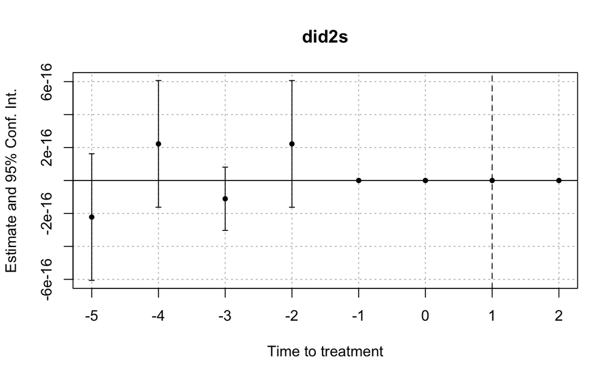

```r
es_mod |>
  fixest::iplot(
    main     = "did2s",
    xlab     = "Time to treatment",
    drop     = "[[:digit:]]{2}",    # Drop any leads/lags greater than |9|
    ref.line = 1
  )
```

### Appendix

```r
skim(data_did2)
```

```
── Data Summary ────────────────────────
                           Values
Name                       data_did2
Number of rows             16
Number of columns          16
_______________________
Column type frequency:
  factor                   1
  logical                  1
  numeric                  14
________________________
Group variables            None
```

|  | skim_variable | n_missing | complete_rate | ordered | n_unique | top_counts |
| --- | --- | --- | --- | --- | --- | --- |
| 1 | post_factor | 0 | 1 | FALSE | 2 | Pre: 10, Pos: 6 |

|  | skim_variable | n_missing | complete_rate | mean | count |
| --- | --- | --- | --- | --- | --- |
| 1 | treat | 0 | 1 | 0.5 | FAL: 8, TRU: 8 |

|  | skim_variable | n_missing | complete_rate | mean | sd | p0 | p25 | p50 | p75 | p100 | hist |
| --- | --- | --- | --- | --- | --- | --- | --- | --- | --- | --- | --- |
| 1 | year | 0 | 1 | 2.016500e+03 | 2.366432e+00 | 2.013000e+03 | 2.014750e+03 | 2.016500e+03 | 2.018250e+03 | 2.020000e+03 | ▇▃▇▃▇ |
| 2 | homicide | 0 | 1 | 3.047500e+02 | 1.580749e+02 | 1.120000e+02 | 1.862500e+02 | 2.705000e+02 | 3.725000e+02 | 6.620000e+02 | ▇▁▆▁▂ |
| 3 | medical_checks | 0 | 1 | 1.036848e+06 | 3.363841e+05 | 4.635950e+05 | 8.440488e+05 | 9.213255e+05 | 1.358669e+06 | 1.543957e+06 | ▂▇▃▁▇ |
| 4 | pop | 0 | 1 | 1.872992e+06 | 8.863085e+05 | 9.919330e+05 | 1.021036e+06 | 1.795008e+06 | 2.714826e+06 | 2.906003e+06 | ▇▁▁▁▇ |
| 5 | ntl | 0 | 1 | 4.274794e+00 | 2.735584e+00 | 1.316300e+00 | 1.682774e+00 | 3.992105e+00 | 6.340194e+00 | 8.383809e+00 | ▇▁▁▅▃ |
| 6 | pm25 | 0 | 1 | 1.298964e+01 | 7.320828e-01 | 1.176809e+01 | 1.251954e+01 | 1.298367e+01 | 1.336690e+01 | 1.422483e+01 | ▃▇▅▅▅ |
| 7 | transit_death | 0 | 1 | 6.338750e+02 | 3.100976e+02 | 2.550000e+02 | 3.780000e+02 | 5.905000e+02 | 9.097500e+02 | 1.118000e+03 | ▇▁▁▃▅ |
| 8 | post | 0 | 1 | 3.750000e-01 | 5.000000e-01 | 0.000000e+00 | 0.000000e+00 | 0.000000e+00 | 1.000000e+00 | 1.000000e+00 | ▇▁▁▁▅ |
| 9 | id | 0 | 1 | 5.000000e-01 | 5.163978e-01 | 0.000000e+00 | 0.000000e+00 | 5.000000e-01 | 1.000000e+00 | 1.000000e+00 | ▇▁▁▁▇ |
| 10 | first_treat | 0 | 1 | 1.009000e+03 | 1.042091e+03 | 0.000000e+00 | 0.000000e+00 | 1.009000e+03 | 2.018000e+03 | 2.018000e+03 | ▇▁▁▁▇ |

[output cut: 4 more lines]

#### Callaway and Sant’Anna 2021

```r
# did - Callaway and Sant’Anna 2021 -  paper Difference-in-Differences with multiple time periods
cs21 = att_gt(
    yname         = "ntl",
    tname         = "year",
    idname        = "id",
    gname         = "first_treat",
  # xformla       = NULL,            # No additional controls in this dataset
    control_group = "nevertreated", # Too few groups for "nevertreated" default
    data          = data_did2
    )
```

Does not run because the groups are too small

#### Sun and Abraham 2020

```r
# fixest - Sun and Abraham 2020 - paper Estimating Dynamic Treatment Effects in Event Studies with Heterogeneous Treatment Effects
sa20 = feols(
    ntl ~ sunab(first_treat, rel_time) | id + year,
    data = data_did2, vcov = ~id
    )
sa20
```

(Standar errors are non finite)